# Red Wine Dataset Analysis

Ola Semsemiah

1/2/2019

========================================================

```
##        X          fixed.acidity   volatile.acidity  citric.acid
##  Min.   :   1.0   Min.   : 4.60   Min.   :0.1200   Min.   :0.000
##  1st Qu.: 400.5   1st Qu.: 7.10   1st Qu.:0.3900   1st Qu.:0.090
##  Median : 800.0   Median : 7.90   Median :0.5200   Median :0.260
##  Mean   : 800.0   Mean   : 8.32   Mean   :0.5278   Mean   :0.271
##  3rd Qu.:1199.5   3rd Qu.: 9.20   3rd Qu.:0.6400   3rd Qu.:0.420
##  Max.   :1599.0   Max.   :15.90   Max.   :1.5800   Max.   :1.000
##  residual.sugar     chlorides       free.sulfur.dioxide
##  Min.   : 0.900   Min.   :0.01200   Min.   : 1.00
##  1st Qu.: 1.900   1st Qu.:0.07000   1st Qu.: 7.00
##  Median : 2.200   Median :0.07900   Median :14.00
##  Mean   : 2.539   Mean   :0.08747   Mean   :15.87
##  3rd Qu.: 2.600   3rd Qu.:0.09000   3rd Qu.:21.00
##  Max.   :15.500   Max.   :0.61100   Max.   :72.00
##  total.sulfur.dioxide    density             pH          sulphates
##  Min.   :  6.00       Min.   :0.9901   Min.   :2.740   Min.   :0.3300
##  1st Qu.: 22.00       1st Qu.:0.9956   1st Qu.:3.210   1st Qu.:0.5500
##  Median : 38.00       Median :0.9968   Median :3.310   Median :0.6200
##  Mean   : 46.47       Mean   :0.9967   Mean   :3.311   Mean   :0.6581
##  3rd Qu.: 62.00       3rd Qu.:0.9978   3rd Qu.:3.400   3rd Qu.:0.7300
##  Max.   :289.00       Max.   :1.0037   Max.   :4.010   Max.   :2.0000
##     alcohol         quality
##  Min.   : 8.40   Min.   :3.000
##  1st Qu.: 9.50   1st Qu.:5.000
##  Median :10.20   Median :6.000
##  Mean   :10.42   Mean   :5.636
##  3rd Qu.:11.10   3rd Qu.:6.000
##  Max.   :14.90   Max.   :8.000
```

# Univariate Plots Section

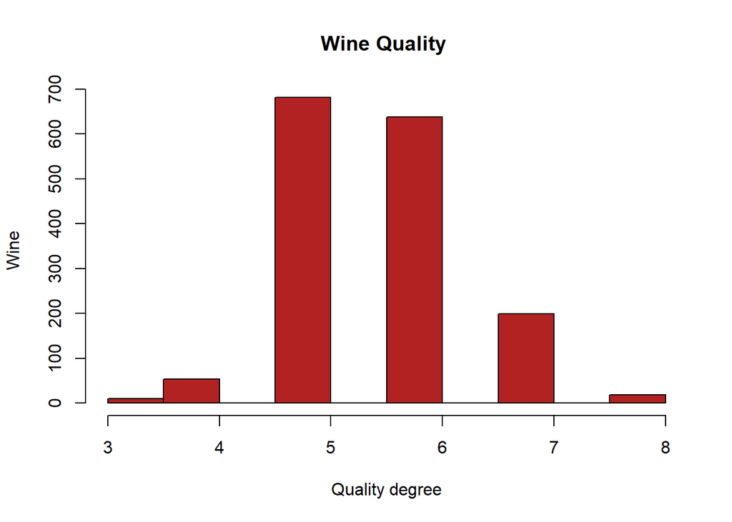

Red wine quality is normally distributed

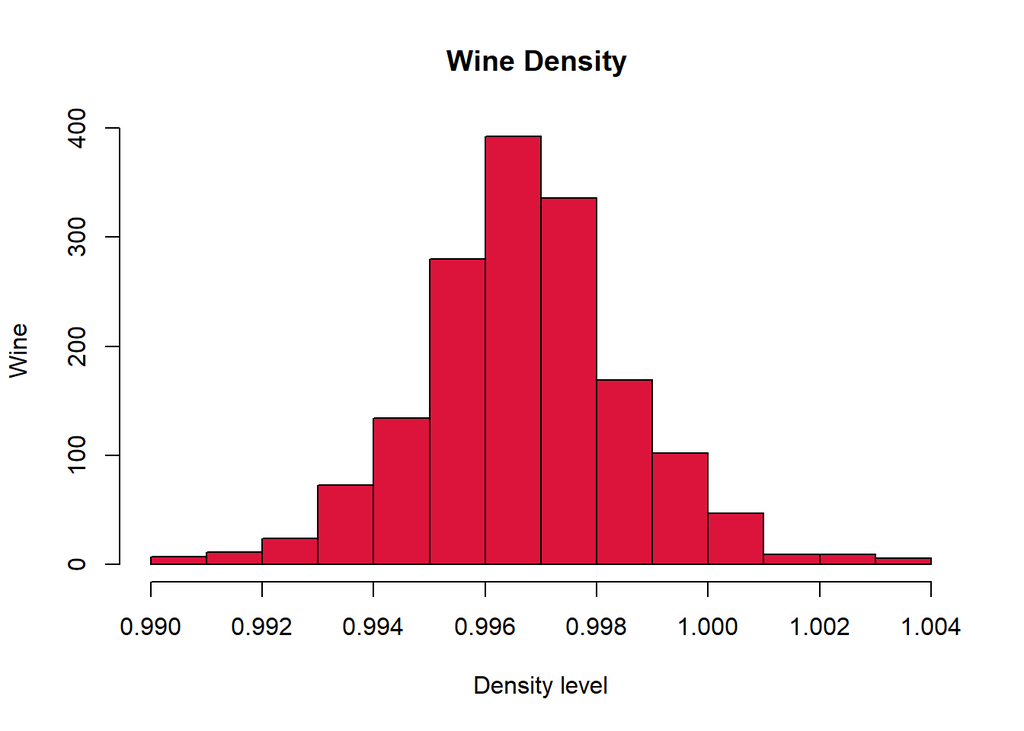

Red wine density is normally distributed

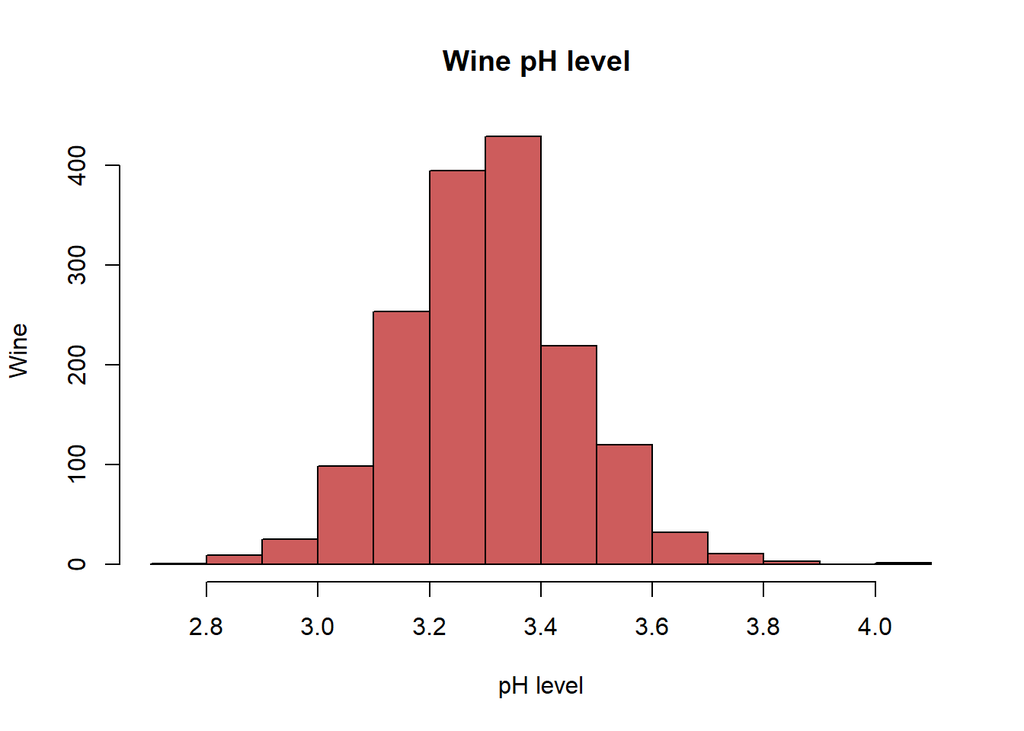

Red wine ph level is normally distributed

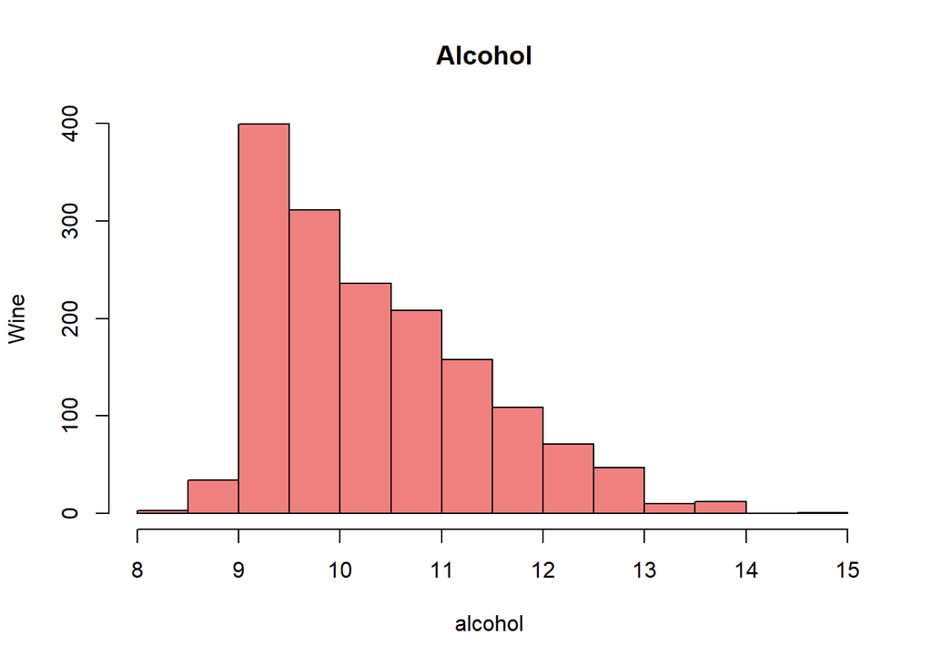

The distribution of alcohol is right skewed

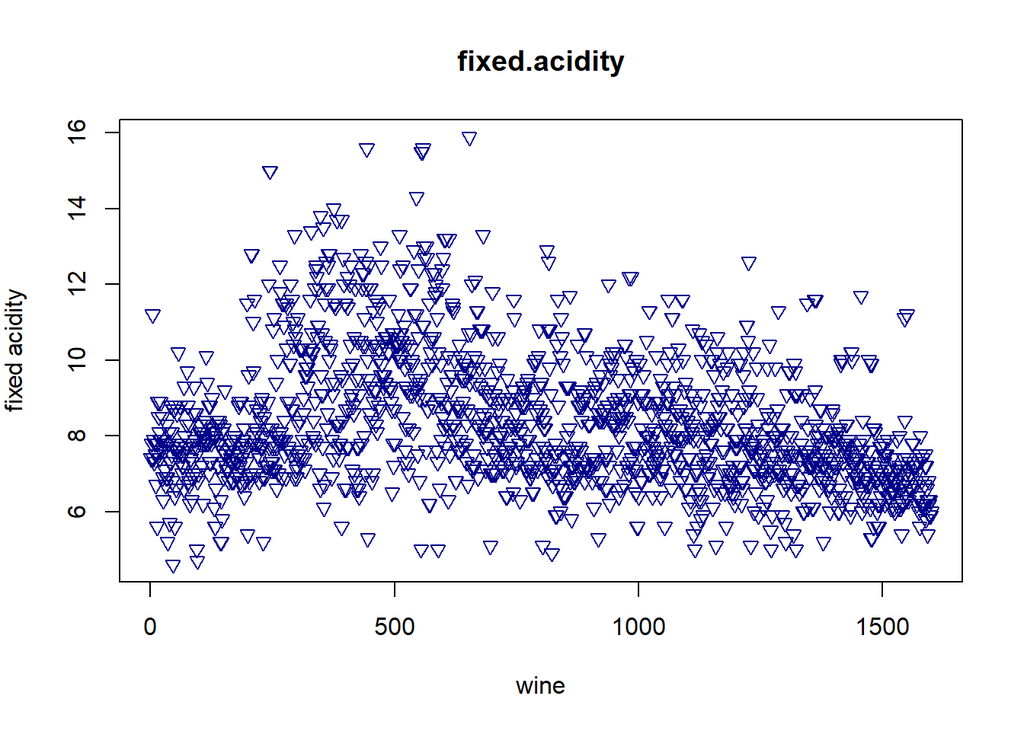

Red wine fixed acidity is right skewed

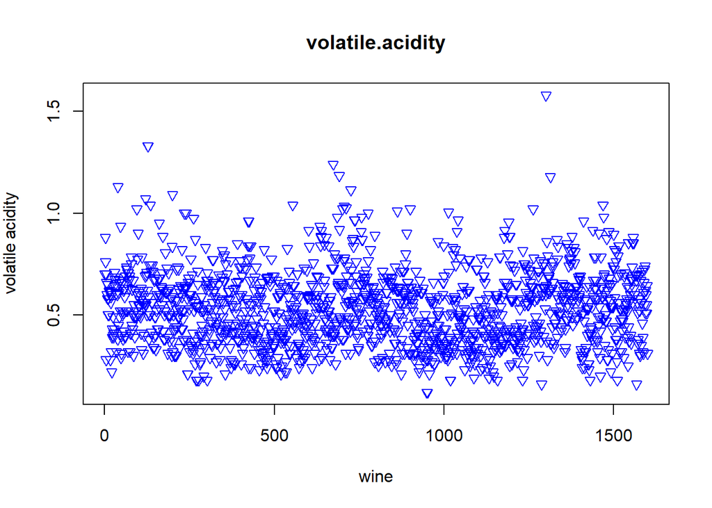

Red wine volatile acidity distribution is unclear (bimodal or unimodel, right skewed or normal).

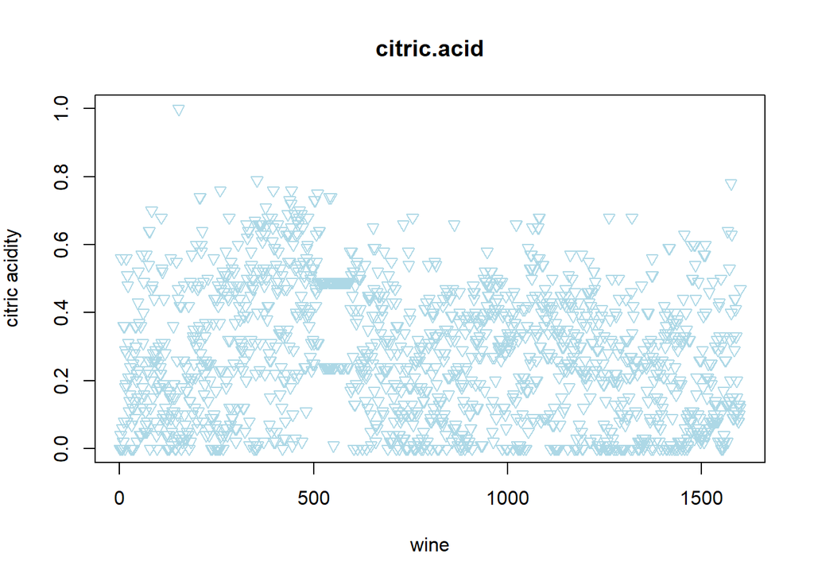

Red wine citric acid distribution is not normal .

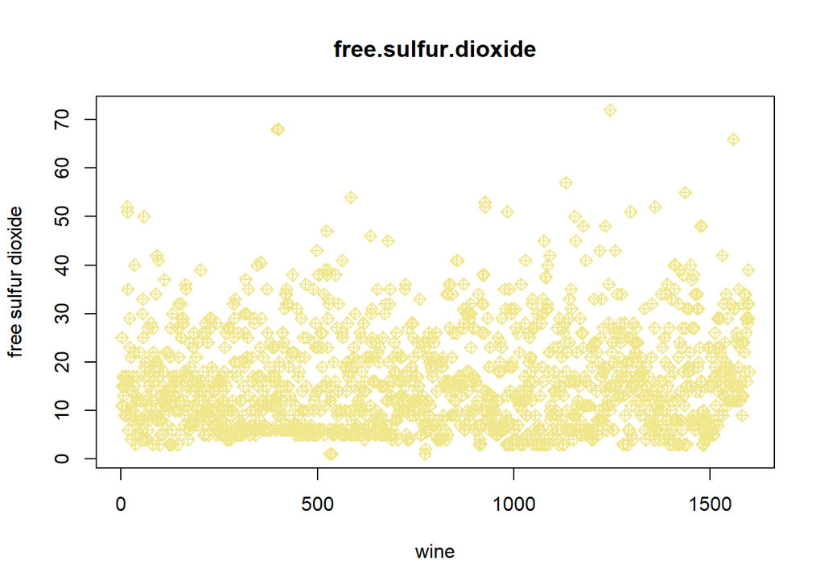

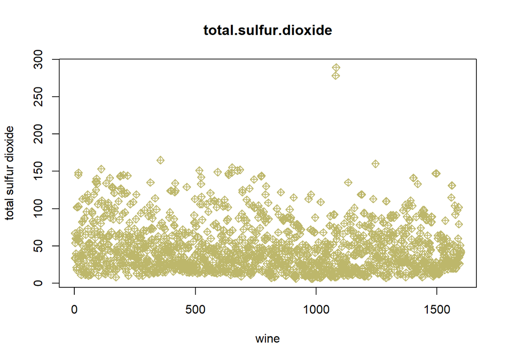

Both total and free dioxide distribuation are right skewed

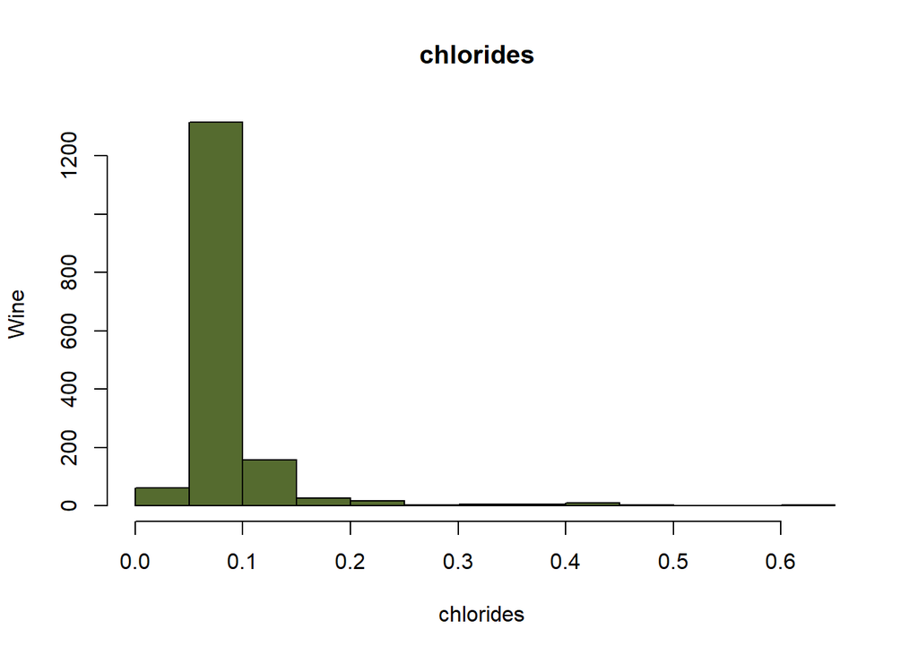

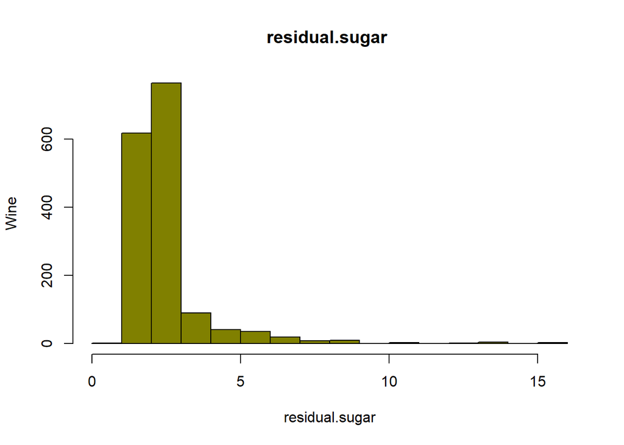

The distribution of residual sugar is right skewed

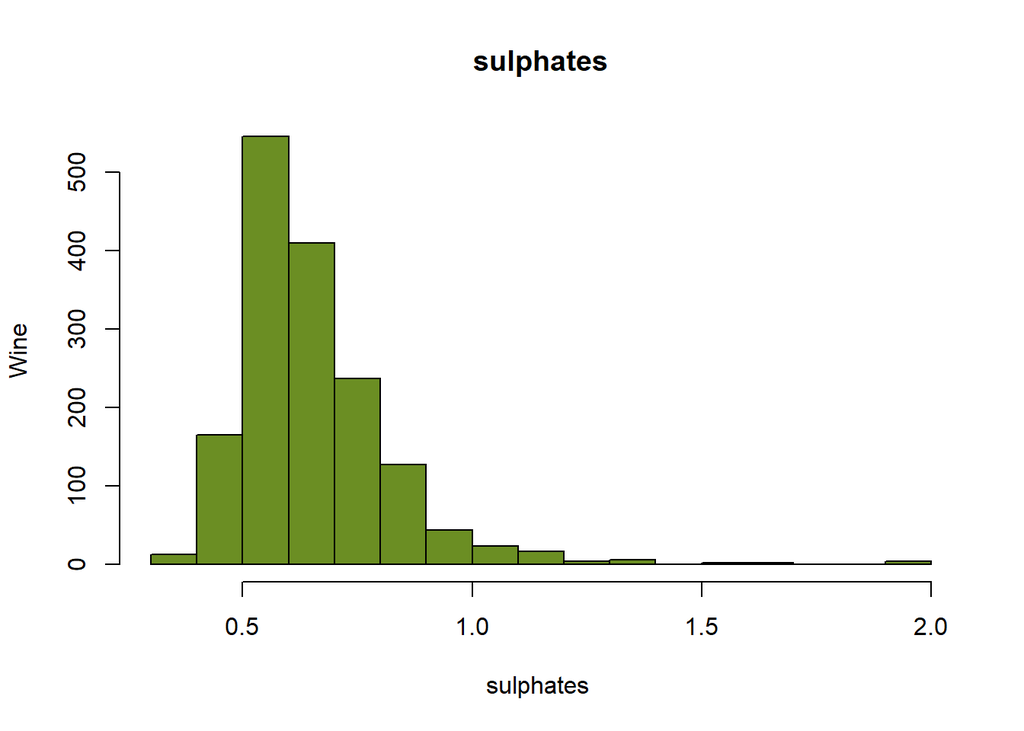

The distribution of sulphates is right skewed

### What is the structure of your dataset?

Data set rows represnt 1,599 red wines Data Set 13 colums represnt red wine features on the chemical properties of the wine (featers are plotted in the previoes section )

### What is/are the main feature(s) of interest in your dataset?

Quality

### What other features in the dataset do you think will help support your investigation into your feature(s) of interest?

Volatile acidity,pH, alcohol

# Bivariate Plots Section

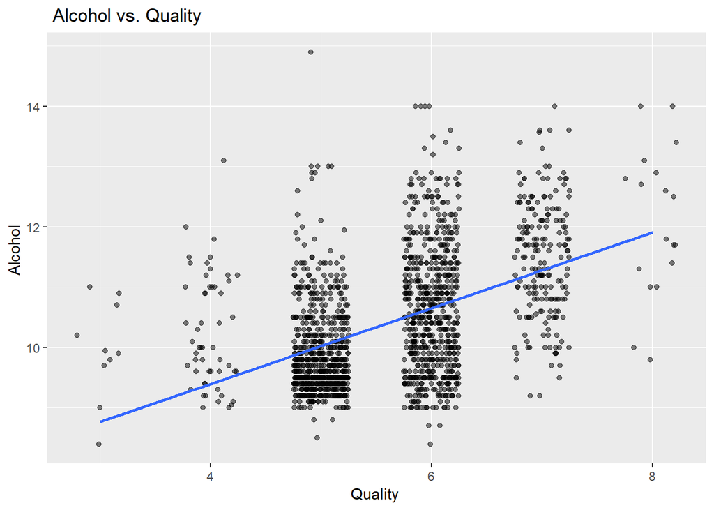

Relationship between Alchoal and wine quality

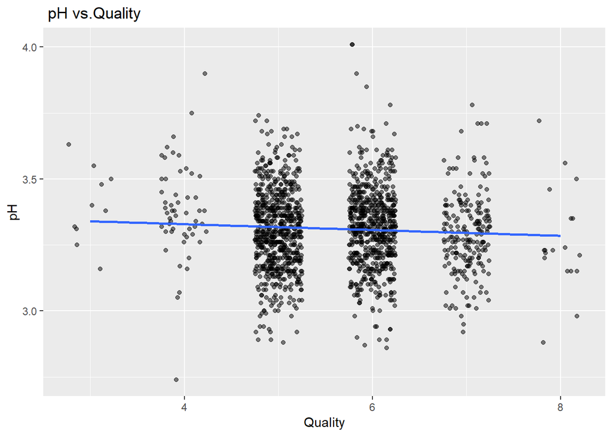

Relationship between pH and wine quality

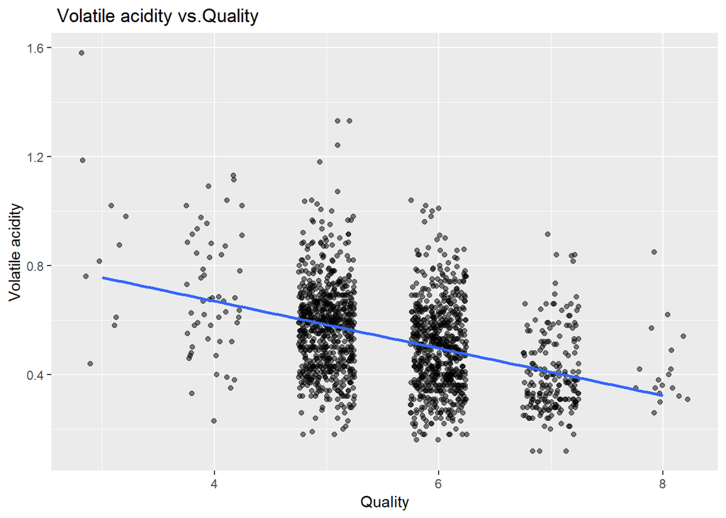

Relationship between Volatile acidity and wine quality

# Bivariate Analysis

### Talk about some of the relationships you observed in this part of the investigation. How did the feature(s) of interest vary with other features in the dataset?

There is a positive relationship between quality degree and alcohol.

### Did you observe any interesting relationships between the other features (not the main feature(s) of interest)?

There is a negative relationship between quality degree and volatile acidity

### What was the strongest relationship you found?

Quality vs Alcohol

# Multivariate Plots Section

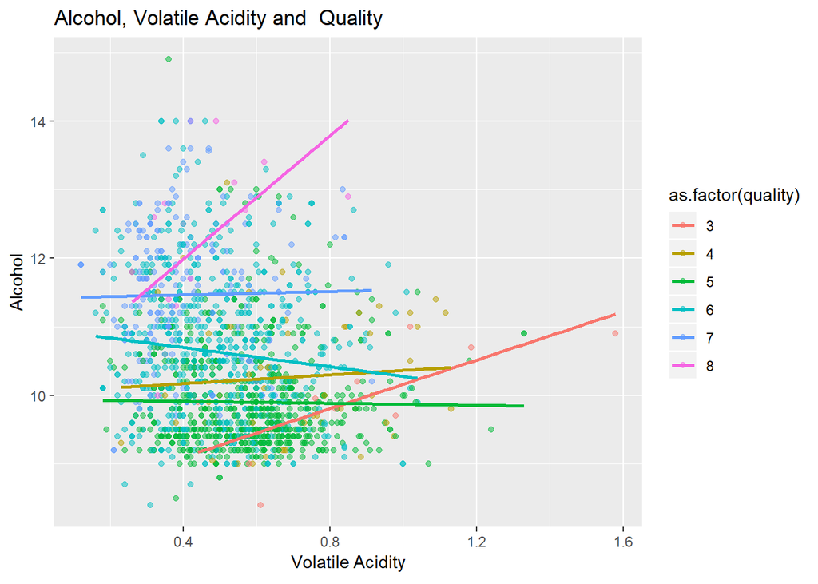

Relationship between Alcohol, Volatile Acidity and Quality

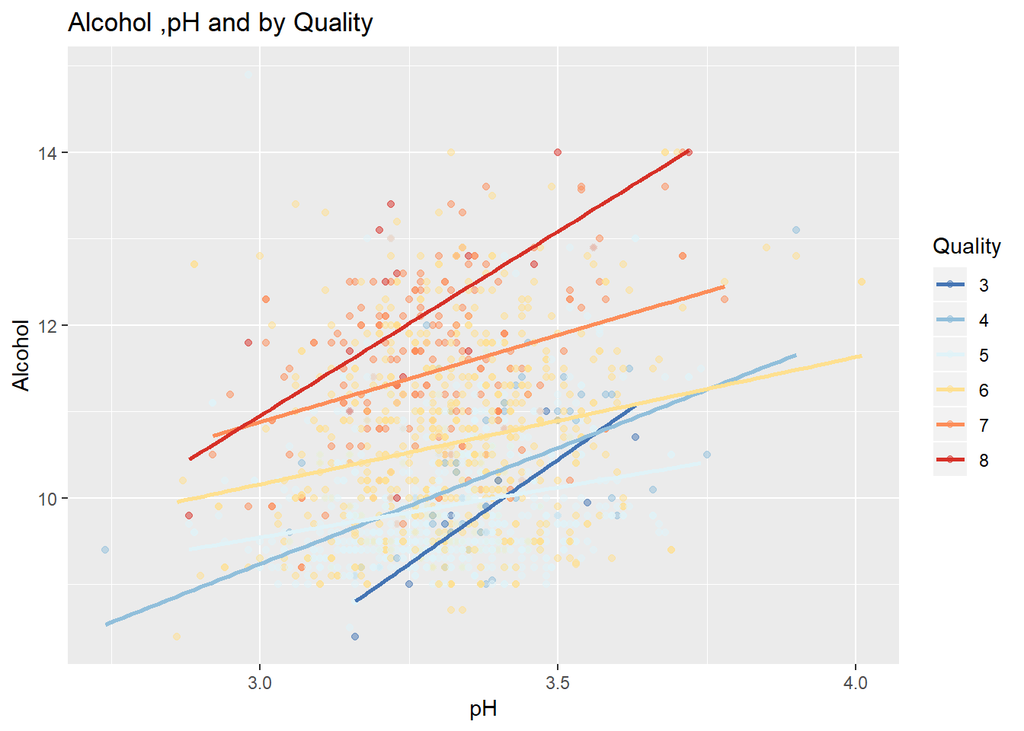

Relationship between Alcohol ,pH and by Quality

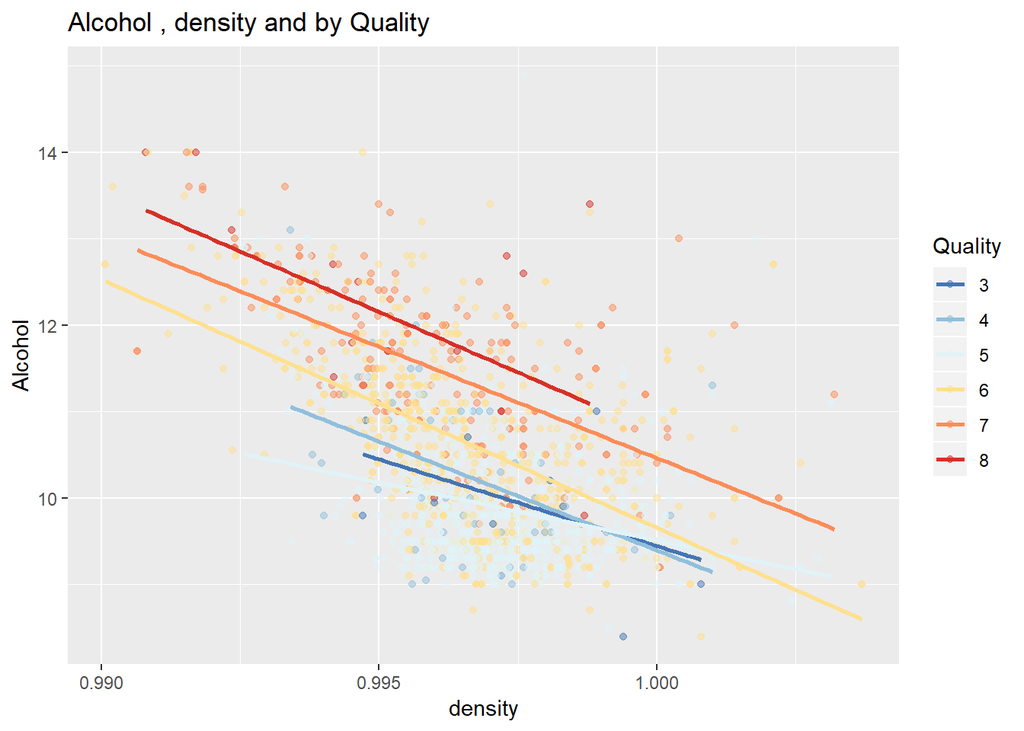

Relationship between Alcohol , density and by Quality

# Multivariate Analysis

# Final Plots and Summary

### Plot One

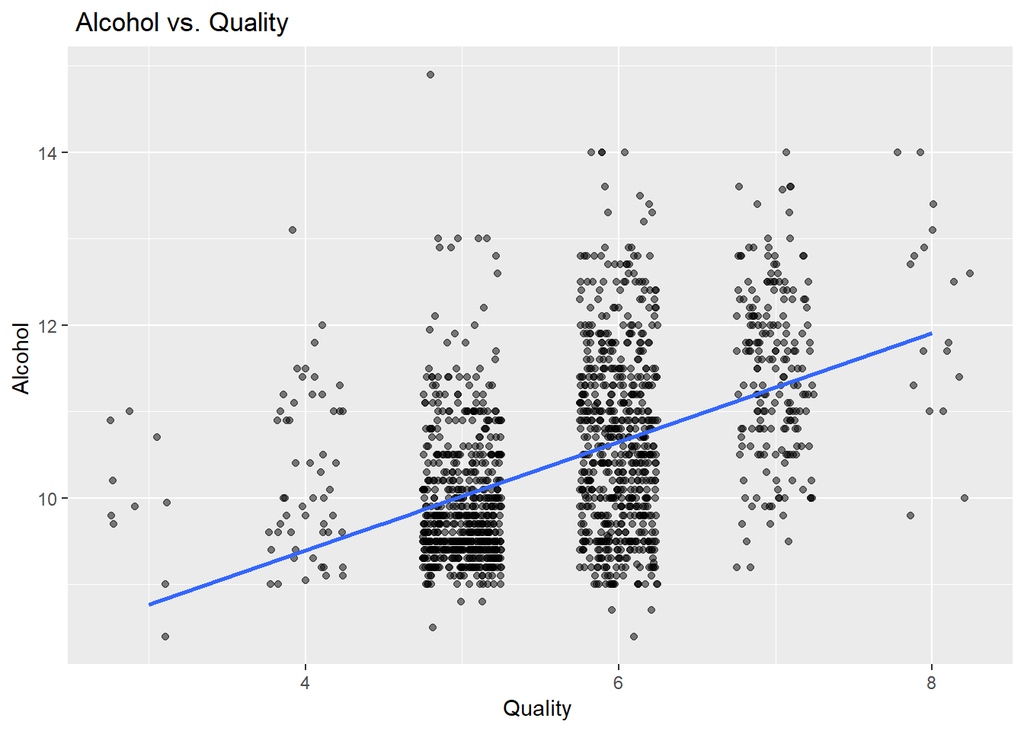

Alcohol percentage has played a big role in determining the quality of Wines

### Plot Two

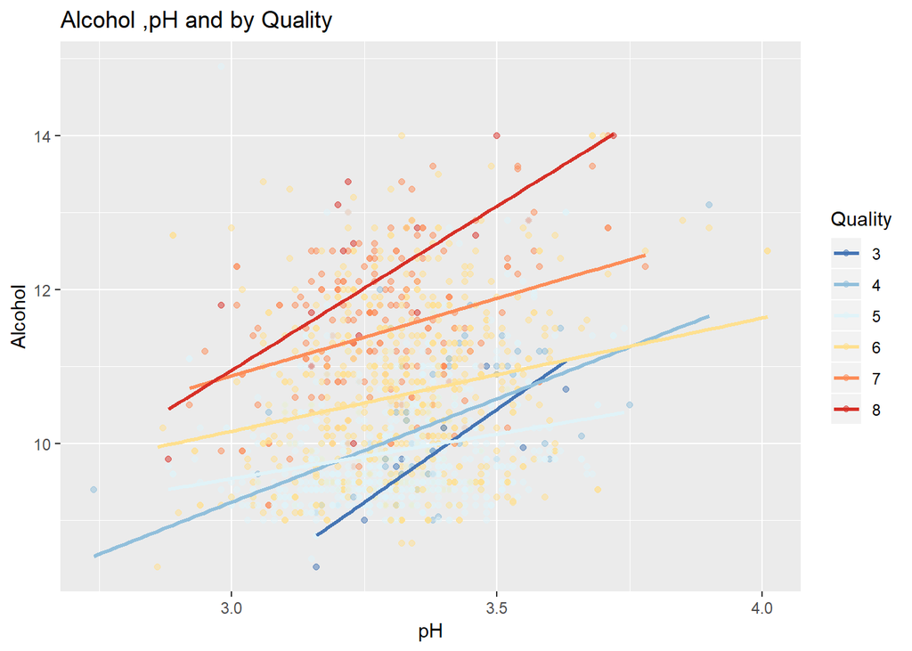

pH affect the quality in a negitive way , More alcohol but less pH produce more quality

### Plot Three

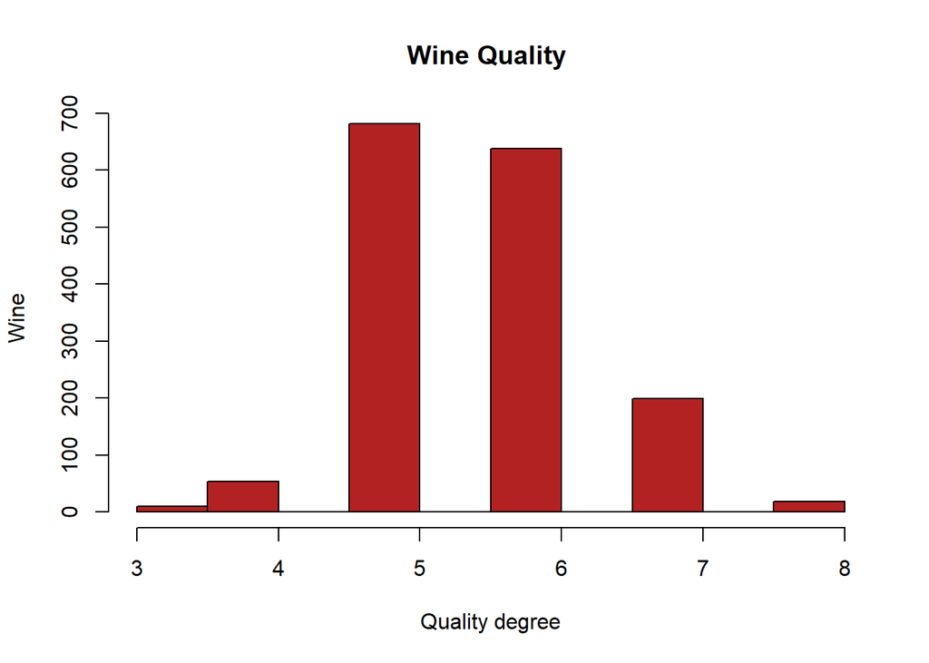

our dataset contains ‘Average’ quality wines and there is not too many data in the extreme ranges, thus it is normally distibuted

# Reflection

- In this project we showed that there are many factors that affect the quality of wine, incresing the level of some factors might have negative or postive effect to the quality dapanding on the factor type
- for this project I needed to see some extra resourses for better understanding
- In genral dataset were enough for predicting the wine quality
- For future analysis, I would love to have a dataset having a rank for the wine by different tasters so I can explore how humen elemnt can affect the quality